# Les prix nobels

Iris Thorimbert

07/11/2021

M1 MIASHS, semestre 7  
Cours de M. CROSETTO, Logiciel spécialisé R

[figure not shown]

## **Base de données**

La base de données ‘Nobel Laureate Publications’ est extraite du projet *TidyTuesday* disponible sur le site *GitHub*. Les données ont été recueillies par Georgios Karamanis qui s’est appuyé sur différents sites internets tels que la page officiel du prix Nobel, celui des universités pour récolter et assembler toutes les informations.

Les prix sont décernés chaque année depuis 1901 à des personnes « ayant apporté le plus grand bénéfice à l’humanité », par leurs inventions, découvertes et améliorations dans différents domaines.

Le premier tableau, *nobel_winners*, contient donc, comme son nom l’indique, le nom des gagnants. Celui-ci est composé de 969 observations et 18 variables telles que l’année du prix (de 1901 à 2016), la catégorie (chimie, physique, littérature, médecine, économie et paix), nom du lauréat, son pays d’origine… Dans le second tableau, nommé *nobel_winner_all_pubs*, nous ai fourni des informations sur les publications écrites par les gagnants. Nous avons un tableau de 93 394 observations et 11 variables. Ainsi nous pouvons y lire, pour chaque vainqueurs, le titre et l’année de chacune de ses publications, la revue dans laquelle elle a été publié, mais également si c’est à partir de ce papier que l’individu a reçu son prix.

A partir de ces informations, nous pouvons à présent commencer notre analyse.

```r
nobel_winners <- readr::read_csv("https://raw.githubusercontent.com/rfordatascience/tidytuesday/master/data/2019/2019-05-14/nobel_winners.csv")

nobel_winner_all_pubs <- readr::read_csv("https://raw.githubusercontent.com/rfordatascience/tidytuesday/master/data/2019/2019-05-14/nobel_winner_all_pubs.csv")
```

Dans un soucis de simplification de la base de données et de son analyse, j’ai fait le choix de supprimer des données. Tout d’abord j’ai enlevé toutes les lignes rattachées au prix Nobel de la paix. En effet, j’obtiens de nombreuses valeurs manquantes et, le fait que des organisations ont parfois été récompensées, cela rend notre analyse plus complexe. Ensuite, dans un second temps, j’ai supprimé les colonnes numéro 13, 14 et 15 correspondant respectivement à *organization_name*, *organization_city* et *organization_country* car celles-ci entraînent un doublon de certain lauréat. C’est donc pour supprimer ces doublons que j’execute la commande *unique*.

```r
# nettoyage de la base de données

nobel <- nobel_winners %>%
  .[!nobel_winners$category=="Peace",] %>%    # suppression de tous les prix associés à Peace
  .[-c(13,14,15)]                             # suppression de ces colonnes

nobel_no_doublon <- unique(nobel[ 1:839,])    # suppression des doublons
```

A partir de maintenant nous avons donc 781 observations et 15 variables.

## **Questions**

#### **1. Combien de prix Nobel ont été gagné par une femme?**

```r
a <- str_count(nobel_no_doublon$gender, 'Female') # créer une matrice 1 et 0
a <- sum(a,na.rm = T)                             # compte le nombre de 1
kable(a, align = "l")
```

| x |
| --- |
| 33 |

#### **2. Qu’est-ce que cela représente par rapport aux hommes?**

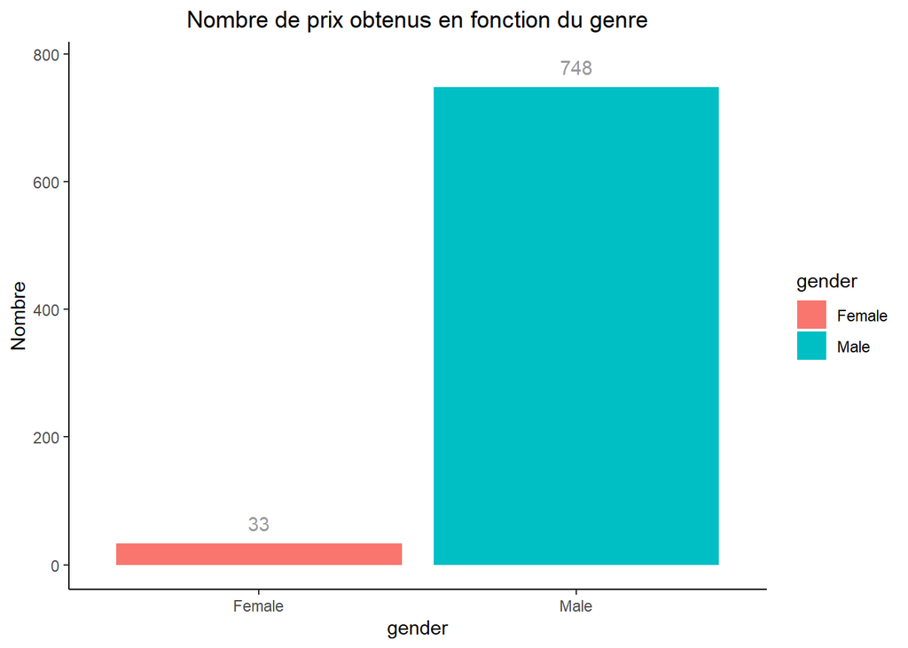

```r
nobel_no_doublon %>%
  select(gender) %>%
  ggplot()+
  aes(x = gender, fill = gender)+
  geom_bar()+
  theme_classic()+
  labs(title = "Nombre de prix obtenus en fonction du genre", y = "Nombre")+
  theme(plot.title = element_text(hjust = 0.5))+
  annotate("text", x = 1, y = 65, label = 33, color = '#999999')+
  annotate("text", x = 2, y = 780, label = 748, color = '#999999')
```

#### **3. Qu’est-ce que cela représente en pourcentage?**

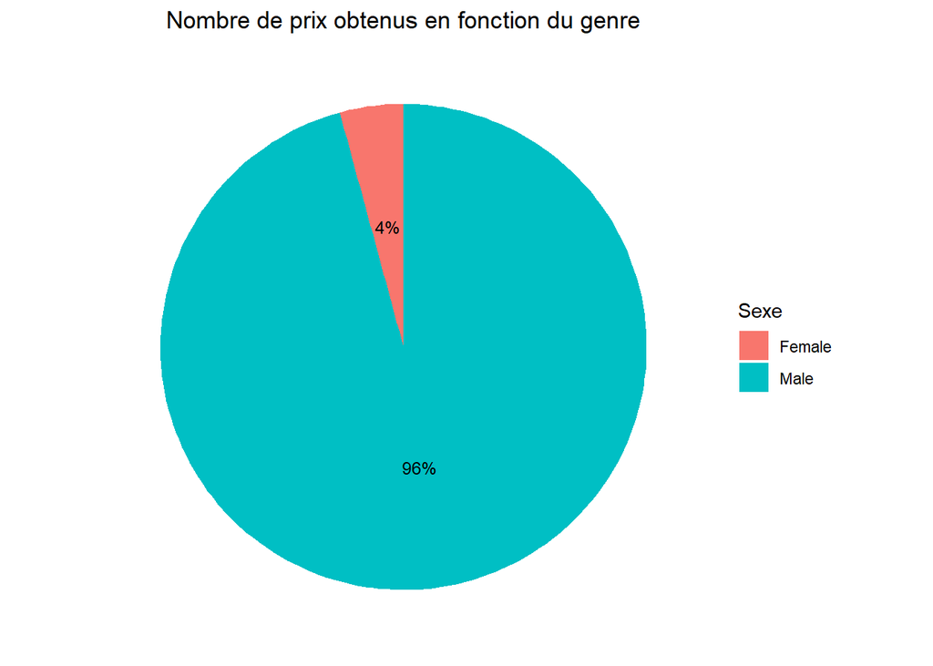

```r
pourcentage_f = 33/781*100
pourcentage_h = 748/781*100
pourcentage_f <- round(pourcentage_f, digits = 2) # 2 chiffres après la virgule
pourcentage_h <- round(pourcentage_h, digits = 2)

# Création d'une table comprennant les pourcentages trouvés au-dessus :
table <- data.frame( Sexe = c("Male", "Female"),
                     Pourcentage = c(pourcentage_h, pourcentage_f))

#graphique en colonne
barre <- table %>%
  ggplot()+
  aes(x = "",y = Pourcentage, fill = Sexe)+
  geom_col()

#transformer en camembert
pie <- barre +
        coord_polar(theta = "y")

#Mise en page du camembert
blank_theme <- theme_minimal() +
  theme(
    axis.title.x = element_blank(),
    axis.title.y = element_blank(),     # on enleve le nom des axes x et y
    panel.border = element_blank(),
    panel.grid=element_blank(),
    axis.ticks = element_blank())+
    theme(axis.text.x = element_blank()) # on enleve les valeurs des axes

pie +
  blank_theme + labs(title = "Nombre de prix obtenus en fonction du genre")+
  theme(plot.title = element_text(hjust = 0.5))+
  geom_text(aes(y = Pourcentage/2 + c(0, cumsum(Pourcentage)[-length(Pourcentage)]),
                label = percent(Pourcentage/100)), size=3.3, color = 'black') # ajout des chiffres
```

#### **4. En quelle année les femmes ont reçu leurs prix?**

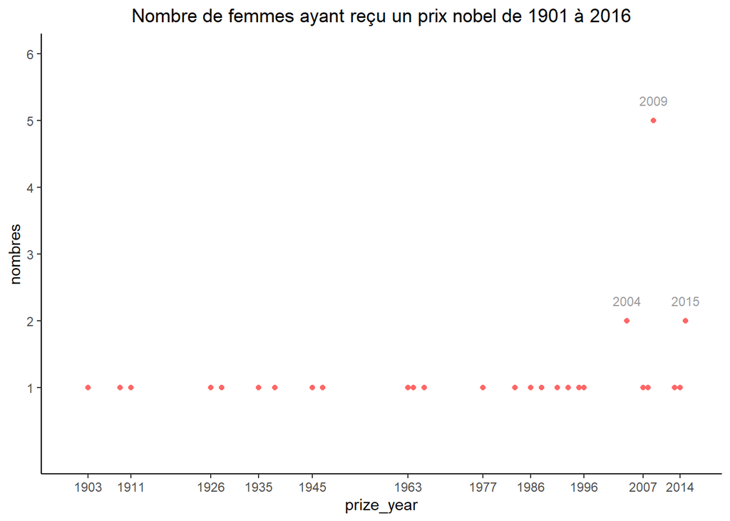

```r
# création d'une base pour faciliter la visualisation
femme <- nobel_no_doublon %>%
  filter(gender == "Female") %>%
  select(prize_year,category, full_name, prize_share)

nobel_no_doublon %>%
  filter(gender =="Female") %>%
  group_by(prize_year ) %>%
  count(prize_year) %>%
  ggplot(aes(x = prize_year, y=n))+
  geom_point(color = "#FF6666")+
  scale_x_continuous(breaks = c(1903, 1911, 1926, 1935, 1945, 1963, 1977, 1986, 1996, 2007, 2014),
                     limits = c(1900,2016))+
  scale_y_continuous(breaks = c(1:6),limits = c(0,6))+
  theme_classic()+
  labs(title = "Nombre de femmes ayant reçu un prix nobel de 1901 à 2016", y = "nombres")+
  theme(plot.title = element_text(hjust = 0.5))+
  annotate("text", x = 2004, y = 2.3, label = 2004, color = '#999999', size = 3)+
  annotate("text", x = 2009, y = 5.3, label = 2009, color = '#999999', size = 3)+
  annotate("text", x = 2015, y = 2.3, label = 2015, color = '#999999', size = 3)
```

**Remarque :** On peut constater qu’en 2009, 5 femmes ont remporté un prix. Sachant que nous analysons ici une base pour 5 prix Nobel : chimie, physique, médecine, littérature et économie (puisque nous avons enlevé le prix Nobel de la paix), nous pouvons donc supposer que toutes les matières ont été gagné par une femme. En revanche, lorsque nous analysons plus en détail la base de données, nous pouvons constater que le prix Nobel de physique a été gagné par un homme. Cela paraît donc étrange et nous fait interroger sur la véracité de nos résultats. Pourtant la raison est parfaitement logique : le prix peut être partager par plusieurs personnes. En effet, nous avons une colonne *prize_share* qui nous permet d’observer avec combien de personne le prix a été partagé. Ainsi, si l’on revient à l’année 2009, nous sommes en mesure de constater que le prix Nobel de médecine à été partagé entre 3 personnes, deux femmes et un homme.

#### **5. Combien d’individus ont partagé un prix à plusieurs?**

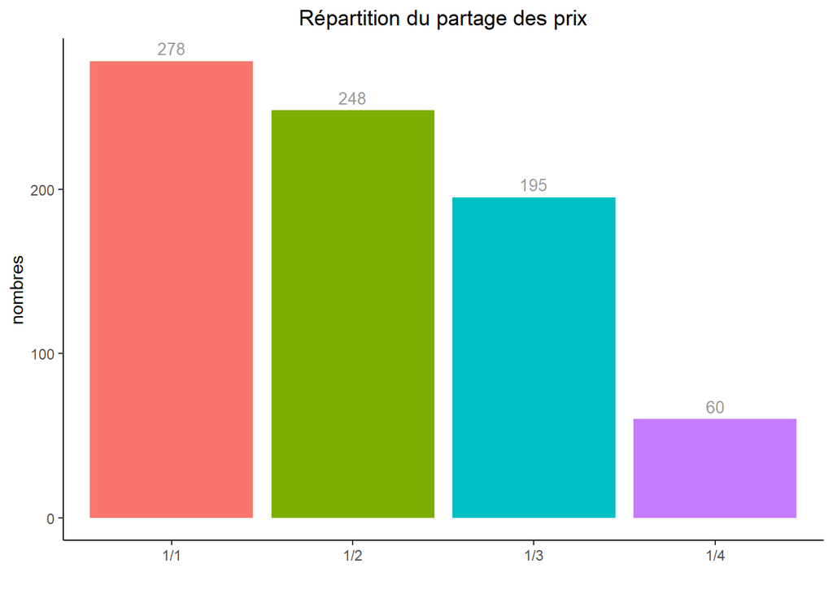

```r
nobel_no_doublon %>%
  group_by(prize_share) %>%
  summarise(N = n()) %>%
  ggplot(aes(prize_share, N, fill = prize_share)) +
  geom_bar(stat = "identity") +
  theme_classic()+
  labs(title = "Répartition du partage des prix", x = "", y = "nombres")+
  geom_text(aes(label = N, vjust = -0.5), color = "#999999", size = 3.5) +
  theme(plot.title = element_text(hjust = 0.5))+
  theme(legend.position='none')
```

#### **6. Par groupe, combien y a-t-il d’hommes et de femmes?**

```r
prix <- nobel_no_doublon %>%
  group_by(gender, prize_share) %>%
  select(gender, prize_share) %>%
  mutate(N = n()) %>%
  unique()

prix2 <- prix %>%
  pivot_wider(names_from = prize_share, values_from = N )

prix2 <- prix2[,c(1,2,3,5,4)]  # les colonnes 4 et 5 etaient inversées

# changement du nom des colonnes
names(prix2)[1]<-"Genre"
names(prix2)[2]<-"1 personne"
names(prix2)[3]<-"2 personnes"
names(prix2)[4]<-"3 personnes"
names(prix2)[5]<-"4 personnes"

# ajout d'une colonne TOTAL
Total = c(748,33)
prix2['Total'] = Total

# affichage du tableau joliment
kable(prix2, align = "l")
```

| Genre | 1 personne | 2 personnes | 3 personnes | 4 personnes | Total |
| --- | --- | --- | --- | --- | --- |
| Male | 262 | 241 | 190 | 55 | 748 |
| Female | 16 | 7 | 5 | 5 | 33 |

#### **7. Combien de nationalité ont obtenu un prix nobel?**

```r
b <- nobel_no_doublon %>%
  select(birth_country) %>%
  unique() %>%
  count()
kable(b, align = "l")
```

| n |
| --- |
| 104 |

Nous avons donc 104 nationalités différentes qui ont un jour gagné un prix nobel. Sachant qu’il y a 195 pays dans le monde, environ un pays sur 2 a un jour été récompensé.  
Cependant ce résultat est également à prendre à la légère car nous prenons ici le pays de naissance du lauréat. Or certain individu ont, entre temps, changer de nationnalité ou travailler dans un autre pays. Nous pouvons prendre comme exemple Marie Curie, né en Pologne puis naturalisée française après son mariage. Le prix nobel de physique qu’elle a obtenu en 1903 est donc affiché dans notre base comme polonais par elle mais également français par son mari Pierre Curie. De plus, comme notre base de donnée commence au début du 20ème siècle, nous avons des pays qui aujoud’hui n’existe plus et qui entraine une augmentation du nombre de pays ayant gagné un prix. Nous avons par exemple *Prussia* qui peut apparaître sous 3 formes :

- Prussia (Poland)
- Prussia (Germany)
- Prussia (Russia)

#### **8. Quel est le top 10 des nationalités les plus nominées?**

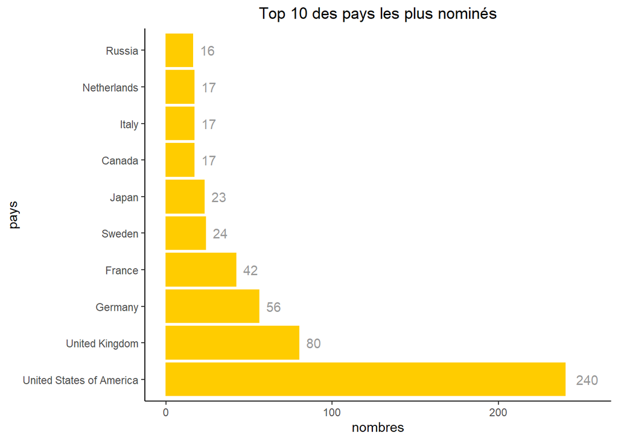

```r
nobel_no_doublon %>%
  group_by(birth_country) %>%
  summarise(N = n()) %>%
  top_n(10) %>%
  ggplot(label = N)+
  scale_x_continuous(limits = c(0,255))+
  aes(y = reorder(birth_country, -N), N)+
  geom_col(color = "#FFCC00", fill="#FFCC00")+
  geom_text(aes(label = N, hjust=-0.5), color="#999999") +
  theme_classic()+
  labs(title = "Top 10 des pays les plus nominés", x = "nombres", y = "pays")+
  theme(plot.title = element_text(hjust = 0.5))
```

Les Etats-Unis récupèrent, loin devant les autres pays, le plus de prix Nobel. A lui seul, il récupère plus de 30% des gagnants.

#### **9. Et le top 5 par matière?**

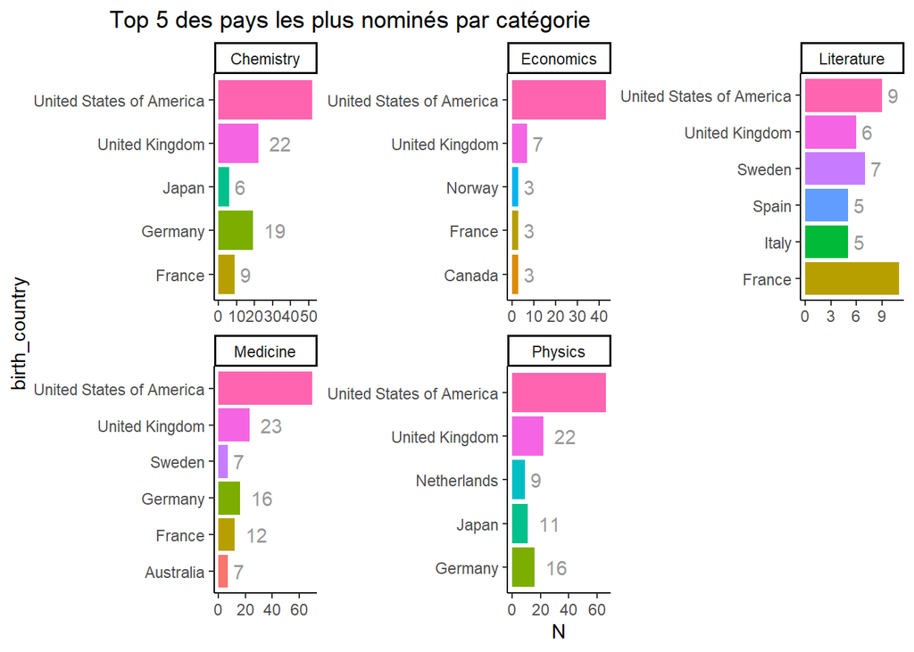

```r
d <- nobel_no_doublon %>%
  group_by(category, birth_country ) %>%
  summarise(N = n()) %>%
  top_n(5) %>%
  unique()

d %>%
  ggplot()+
  aes(x = birth_country, y = N, fill= birth_country)+
  geom_col()+
  facet_wrap(~category, scales = "free") +
  coord_flip()+
  geom_text(aes(label = N, hjust=-0.5), color="#999999") +
  theme_classic()+
  labs(title = "Top 5 des pays les plus nominés par catégorie", )+
  theme(plot.title = element_text(hjust = -0.5))+
  theme(legend.position='none')
```

Ces résultats ne sont pas surprenants. Comme nous l’avons vu juste avant, les Etats-Unis sont le pays le plus récompensé, suivi ensuite du Royaume-Uni. C’est donc sans surprise que ces deux pays arrivent en tête dans quasiment toutes les catégories. On peut tout de même constater que le prix Nobel de littérature n’est pas gagné en majorité par les Etats-Unis mais par la France avec 11 gagnants, suivit de près par leur concurrent américain avec 9.

#### **10. Combien de personnes ont obtenu plusieurs prix Nobel?**

```r
# compte du nombre de fois où le nom apparait
multiple <- nobel_no_doublon %>%
  group_by(full_name) %>%
  summarise(N = n())

#on ne garde que ceux qui apparaissent plus de 1 fois
multiple2 <- multiple %>%
  filter(multiple$N > 1)

kable(multiple2, align = "l")
```

| full_name | N |
| --- | --- |
| Frederick Sanger | 2 |
| John Bardeen | 2 |
| Marie Curie, née Sklodowska | 2 |

Nous voyons donc que 3 personnes ont obtenu deux fois un prix Nobel. Voyons maintenant si leurs prix ont été reçu dans la même matière.

**Remarque :** A la première question, nous nous demandons combien de prix Nobel ont été remporté par une femme. Nous avions obtenu le résultat de 33. A partir de cette nouvelle question, nous pouvont donc conclure qu’au total 32 femmes ont reçu un prix Nobel entre 1901 et 2016.

#### **11. Parmi ces 3 personnes, combien en ont obtenu dans deux matières différentes?**

```r
z <- nobel_no_doublon %>%
  select(full_name,category,prize_year) %>%
  filter(full_name %in% c("Frederick Sanger","John Bardeen" ,"Marie Curie, née Sklodowska"))

z1 <- z[order(z$full_name),]

kable(z1,align = "l")
```

| full_name | category | prize_year |
| --- | --- | --- |
| Frederick Sanger | Chemistry | 1958 |
| Frederick Sanger | Chemistry | 1980 |
| John Bardeen | Physics | 1956 |
| John Bardeen | Physics | 1972 |
| Marie Curie, née Sklodowska | Physics | 1903 |
| Marie Curie, née Sklodowska | Chemistry | 1911 |

Nous pouvons donc conclure que Marie Currie est la seule personne dans l’histoire des prix Nobel a en avoir obtenu dans deux domaines différents : celui de physique en 1903 et de chimie en 1911.